# QVT_Prof_Santé_Sud_Cameroun

Nansseu JR

2025-07-04

# Présentation

Cette analyse présente les résultats issus de l’enquête sur la qualité de vie au travail (QVT) des personnels de santé de neuf formations sanitaires du Sud Cameroun.

# Importation des packages et base de donnnées

La base de données contient 209 observations et 48 variables. Les résultats sont donc présentés pour 209 participants.

# 1. Analyses univariées

Le tableau ci-dessous présente les différentes frésuences absolues et pourcentages de chaque modalité des variables renseignées.

| **Characteristic** | **N = 209**<sup>1</sup> |
| --- | --- |
| id | 127 (68, 180) |
| age_group |  |
| 25 - 34 ans | 74 (35%) |
| 35 - 44 ans | 83 (40%) |
| 45 ans et plus | 40 (19%) |
| Moins de 25 ans | 12 (5.7%) |
| gender |  |
| Femme | 151 (72%) |
| Homme | 58 (28%) |
| marital_status |  |
| Célibataire | 127 (61%) |
| Divorcé(e) | 1 (0.5%) |
| Marié(e) | 74 (35%) |
| Veuf(ve) | 7 (3.3%) |
| dependents |  |
| 1 à 2 | 52 (25%) |
| 3 à 5 | 76 (36%) |
| Aucune | 18 (8.6%) |
| Plus de 5 | 63 (30%) |
| profession_cat |  |
| Aide-soignant(e) | 60 (29%) |
| Autre | 5 (2.4%) |
| Infirmier(e) | 81 (39%) |
| Personnel Médical (Médecin, Pharmacien CD) | 25 (12%) |
| Sage-femme / Maïeuticien(ne) | 9 (4.3%) |
| Technicien(ne) de laboratoire | 29 (14%) |
| profession_cat_other |  |
| Aps | 3 (30%) |
| Chirurgien Dentiste | 1 (10%) |
| Commis De Pharmacie | 2 (20%) |

[output cut: 263 more lines]

<sup>1</sup> Median (Q1, Q3); n (%)

## 1.2 Quelques graphiques

### a- Tranches d’âges par sexe

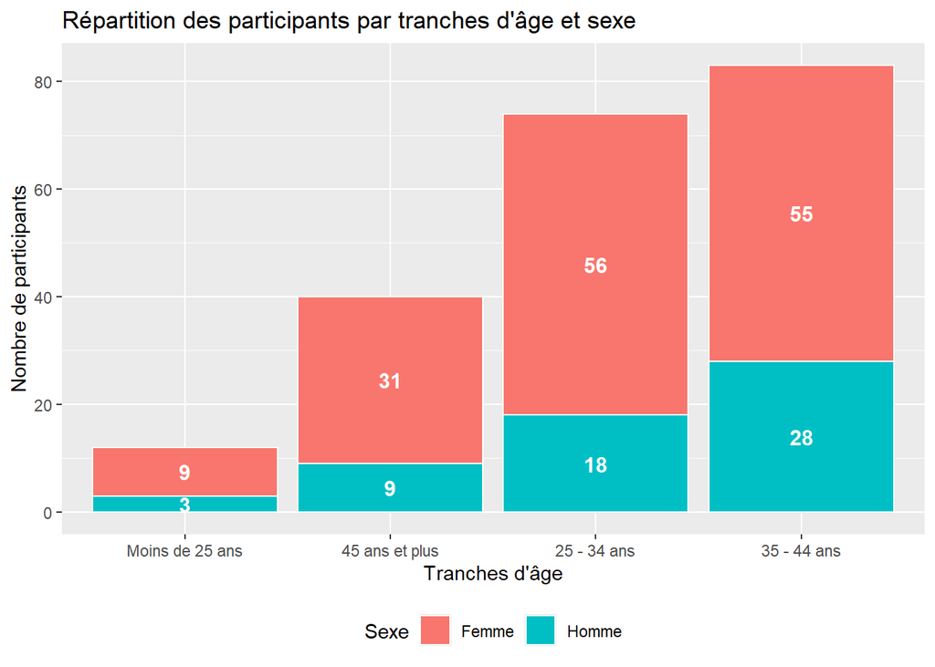

La tranche d’âge la plus représentée est celle des 35-44 ans (n = 83; 40%). le sexe ratio est de 0.38H/1F.

### b- Catégorie professionnelle par type de formation sanitaire (FOSA)

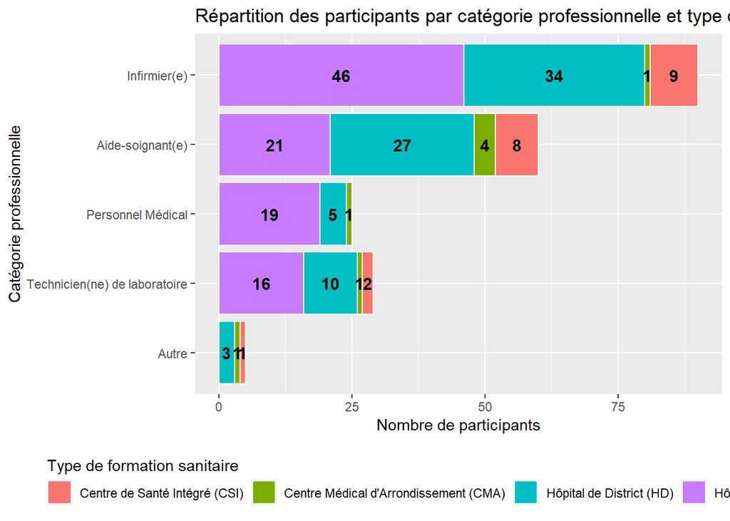

### c-Catégorie professionnelle par FOSA enquêtée

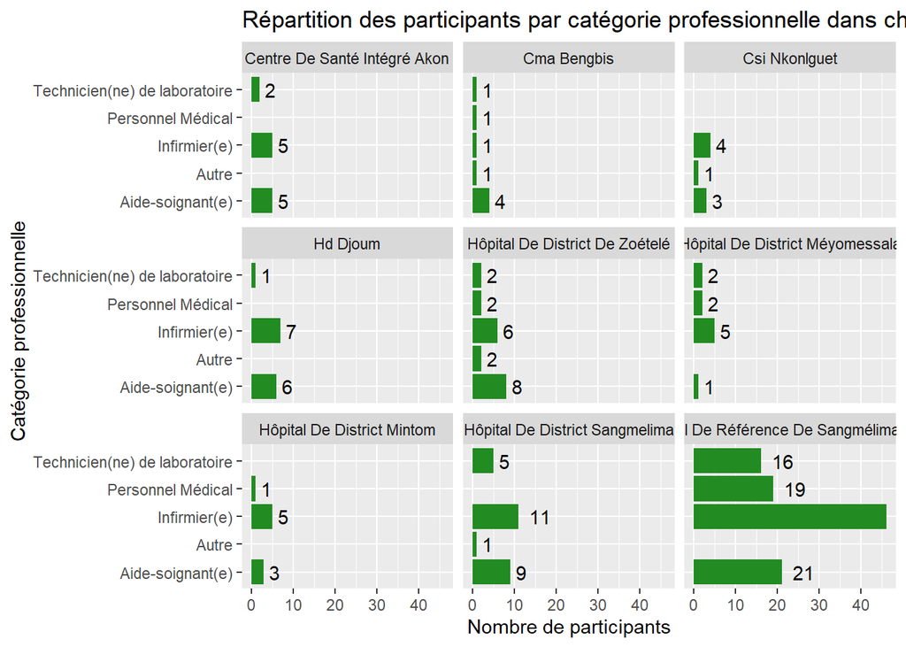

### d- Rôle à l’hôpital par FOSA enquêtée

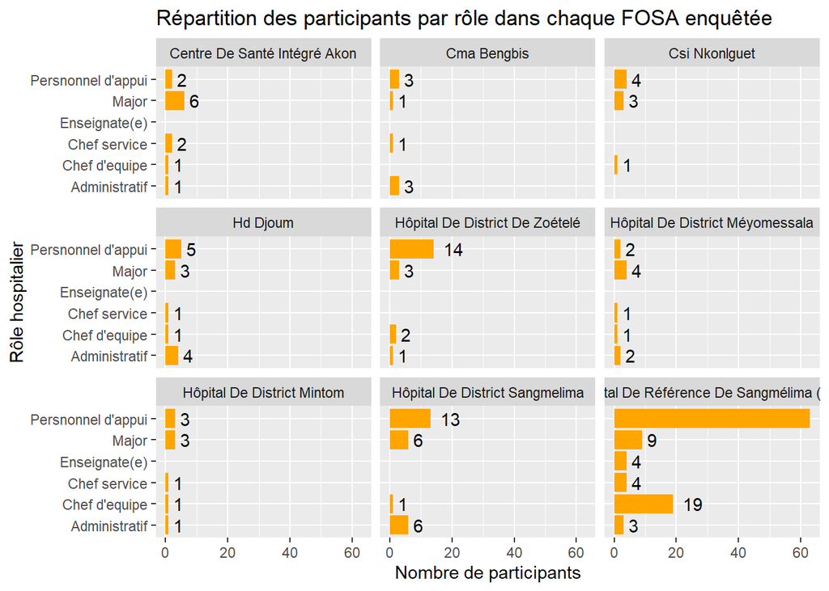